# Lesson Goals

In this lesson i will walk you through how to analyze Digital Elevation Model(DEM) and we save it as a GIS shapefile . We will also visualize the slope aspect ratio which is very crucial finding for land development

# Prerequests

1. Install rasterio
2. Install geopandas
3. Install shapely
4. install richdem

   NB:you can collect the dataset from EarthData NASA website

```python
import richdem as rd
import rasterio
from rasterio import plot
import geopandas as gpd
from shapely.geometry import Point

%matplotlib inline
```

# create a dataset object using the DEM geotiff file `maryland.tif`

```python
maryland_rio_ds = rasterio.open('./maryland.tif')
```

## get dataset's coordinate system

```python
maryland_rio_ds.crs
```

```
CRS.from_epsg(4326)
```

## get dataset's number of bands

```python
maryland_rio_ds.count
```

```
1
```

## get dataset's bounds

```python
maryland_rio_ds.bounds
```

```
BoundingBox(left=-77.0001388888889, bottom=35.99986111111112, right=-75.99986111111112, top=37.0001388888889)
```

## get dataset's width and height in pixels

```python
raster_width = maryland_rio_ds.width
raster_height = maryland_rio_ds.height

'width= {}, height={}'.format(raster_width,raster_height)
```

```
'width= 3601, height=3601'
```

## plot the dataset, DEM

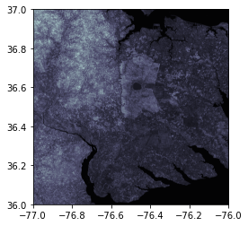

```python
rasterio.plot.show(maryland_rio_ds,cmap='bone')
```

## create a band1 object

### *** bands in dataset are numpy arrays

```python
maryland_rio_band1 = maryland_rio_ds.read(1).astype('float64')
```

## get pixel value by passing row & col from band1

```python
maryland_rio_band1[1,5]
```

```
37.0
```

## get longitude & latitude coordinates by passing row & column

*you cannot get longitude & latitude coordinates from a dataset band since it is only a numpy array*

```python
maryland_rio_ds.xy(1,5)
```

```
(-76.99861111111113, 36.99972222222223)
```

## create a richdem object using band1

```python
maryland_richdem = rd.rdarray(maryland_rio_band1, no_data=-9999)
```

## now plot the richdem object

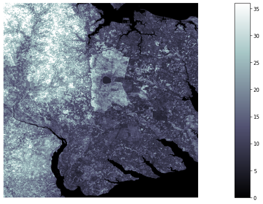

```
{'vmin': 0.0, 'vmax': 36.0}
```

```python
rd.rdShow(maryland_richdem, axes=False, cmap='bone', figsize=(9, 6))
```

# create slope raster using richdem

```python
maryland_rich_slope = rd.TerrainAttribute(maryland_richdem, attrib='slope_degrees')
```

# plot slope values

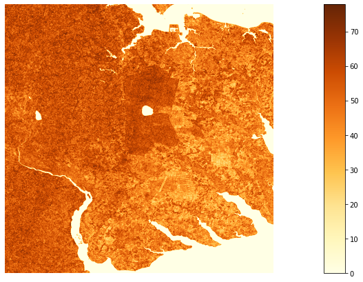

```
{'vmin': 0.0, 'vmax': 77.83824920654297}
```

```python
rd.rdShow(maryland_rich_slope, axes=False, cmap='YlOrBr', figsize=(9, 6))
```

# create aspect using richdem

```python
maryland_rich_aspect = rd.TerrainAttribute(maryland_richdem, attrib='aspect')
```

# plot aspect values

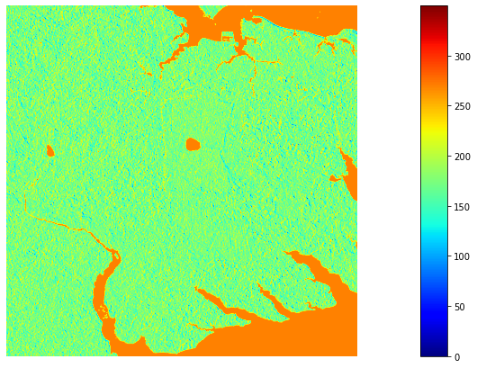

```
{'vmin': 0.0, 'vmax': 349.6951599121094}
```

```python
rd.rdShow(maryland_rich_aspect, axes=False, cmap='jet', figsize=(9, 6))
```

## generate a dictionary of the following lists:

- geometry point objects (shapely geomteries)
- Attributes : elvation, slope, and aspect

```python
pnt_data = {'elevation':[],'slope':[],'aspect':[],'geometry':[]}

width_step = 7
height_step = 200

for i in range(0,raster_width,width_step):
    if i % 47 == 0 and i != 0:
        for j in range(200,raster_height-height_step,height_step):
            pnt_data['elevation'].append(round(maryland_richdem[i,j],2))
            pnt_data['slope'].append(round(maryland_rich_slope[i,j],2))
            pnt_data['aspect'].append(round(maryland_rich_aspect[i,j],2))
            pnt_data['geometry'].append(Point(maryland_rio_ds.xy(i,j)))
```

## Create a geopandas dataframe from the dictionary

```python
gp_df = gpd.GeoDataFrame(pnt_data, crs="EPSG:4326")
```

## export the geopandas datafrane to geojson

```python
gp_df.to_file('./random_pnts.geojson', driver="GeoJSON")
```

## export the geopandas datafrane to shapefile

```python
gp_df.to_file('./random_pnts.shp', driver="ESRI Shapefile")
```

# Further reading

1.PyGran: An object-oriented library for DEM simulation and analysis [link](https://www.sciencedirect.com/science/article/pii/S2352711018301080).

2.pyDEM: Global Digital Elevation Model Analysis [link](http://conference.scipy.org/proceedings/scipy2015/pdfs/mattheus_ueckermann.pdf).

3.RichDEM: High-Performance Terrain Analysis [link](https://peerj.com/preprints/27099.pdf)

## 7. Conclusion

The work described in this notebook is shows how to import DEM and analysis. Specifically

- how to know the property of raster file
- how to create slope and how to create aspect
- how to generate dictionary and create geodataframe
- how to save our dataset into shapefile(.shp)

# Next Step

There is still much room to use this analysis for further study like for estimating a region’s hydrologic and geomorphic properties, including soil moisture, terrain stability, erosive potential, rainfall retention, and stream power. I'll write another one for this.